# p8105_hw6_ej2520

Erynne Jackson

2024-12-02

## Problem 2

Cleaning up the homicide dataset. Here , we are adding the new `city_state` variable, creating a variable for solved/unsolved cases, and removing Dallas,TX, Phoenix,AZ, Kansas City, MO, and Tulsa, AL. I filtered the dataset to only include `victim_race` with Black and White. I change the `victim_age` variable to numeric.

```r
Homicide = read_csv("homicide-data.csv")
homicide_new =
  Homicide |>
  mutate(city_state = paste(city, state, sep = ",")) |>
  mutate(case_solved = ifelse(disposition == "Closed by arrest", "1", "0")) |>
  filter(!city_state %in% c("Dallas,TX", "Phoenix,AZ", "Kansas City,MO", "Tulsa,AL")) |>
  filter(victim_race %in% c("White", "Black")) |>
  mutate(victim_age = as.numeric(victim_age)) |>
  mutate(case_solved = as.numeric(case_solved))
```

Running `glm` for Baltimore,MD, with race, sex, and age as predictor variables.

```r
Baltimore_df =
  homicide_new |>
  filter(city_state == "Baltimore,MD")

fit_logistic =
  Baltimore_df |>
  glm(case_solved ~ victim_age + victim_race + victim_sex, data =_, family = binomial())

fit_logistic |>
  broom::tidy() |>
  mutate(OR = exp(estimate)) |>
  select(term, log_OR = estimate, OR, p.value) |>
  knitr::kable(digits = 3)
```

| term | log_OR | OR | p.value |
| --- | --- | --- | --- |
| (Intercept) | 0.310 | 1.363 | 0.070 |
| victim_age | -0.007 | 0.993 | 0.043 |
| victim_raceWhite | 0.842 | 2.320 | 0.000 |
| victim_sexMale | -0.854 | 0.426 | 0.000 |

Getting the odds ratio for female vs. male.

```r
OR_sex = tidy(fit_logistic)

OR_sex |>
  filter(term == "victim_sexMale") |>
  mutate(odds_ratio = exp(estimate),
    ci_low = exp(estimate - 1.96 * std.error),
    ci_high = exp(estimate + 1.96 * std.error)) |>
  knitr::kable(digits = 4)
```

| term | estimate | std.error | statistic | p.value | odds_ratio | ci_low | ci_high |
| --- | --- | --- | --- | --- | --- | --- | --- |
| victim_sexMale | -0.8545 | 0.1382 | -6.1839 | 0 | 0.4255 | 0.3246 | 0.5579 |

The odds of solving the case for male victims are 0.426 times the odds of solving a case for female victims, after controlling for age and race.We are 95% confident that the true odds ratio lies between 0.3245 and 0.5579.

```r
All_cities = homicide_new |>
  group_by(city_state) |>
  nest() |>
  mutate(
    model =
      map(data, ~glm(case_solved ~ victim_age + victim_race + victim_sex, data=.x, family = binomial())),
    final_model= map(model, ~broom::tidy(.x, conf.int =TRUE, exponentiate = TRUE)))|>
  unnest(cols = final_model) |>
    filter(term == "victim_sexMale") |>
  select(city_state, estimate, conf.low, conf.high)
```

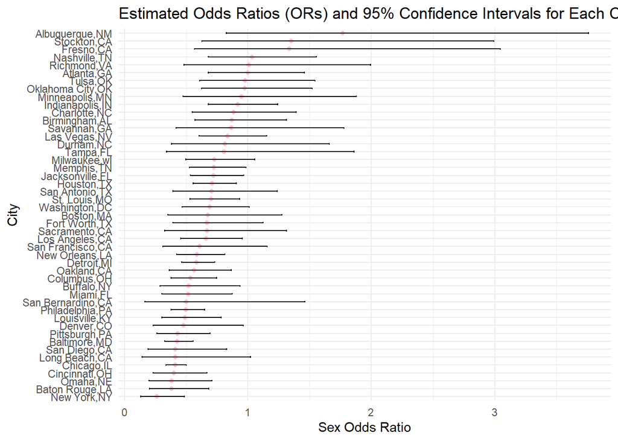

```r
ggplot(All_cities, aes(x = reorder(city_state, estimate), y = estimate)) +
  geom_point(color = "pink") +
  geom_errorbar(aes(ymin = conf.low, ymax = conf.high), width = 0.2) +
  coord_flip() +
  xlab("City") +
  ylab("Sex Odds Ratio") +
  theme_minimal() +
  ggtitle("Estimated Odds Ratios (ORs) and 95% Confidence Intervals for Each City")
```